# Analyses Pilot

Mora Maldonado

6/30/2017

# TODO and comments

- Include in this file rough predictions
- Decide exclusion criteria (based on accuracy and time)
- There seem to be no differences in time (maybe more time pressure?)
- Stats won’t work with this amount of subjects, specially given that we have to take subjects out. Also, just by eye there is nothing in the online data.

## Charging packages

*[HIDDEN]*

## Chargind data

FYI: *data* contains all the results, *experimental_items* contains only results for experimental trials

```r
data <- read.csv("PilotResults.csv")
data <- data[!apply(is.na(data) | data == "", 1, all),]
info <- read.csv("PilotInfo.csv")
```

### Organizing a little bit

**Printing type of data in each column to check whether everything is right**

```r
data$Subject <- factor(data$Subject)
data$Type <- factor(data$Type)
data$Condition <- factor(data$Condition)
data$Response <- factor(data$Response)
data$X <- factor(data$X)
data$Response.Numeric <- data$Response
levels(data$Response.Numeric) <- c(2,1,3,0)
data$Response.Numeric <- as.numeric(as.character(data$Response.Numeric))
data$Chunk.Time.Log <- log(data$Chunk.Time)
data$Total.Time.Log <- log(data$Total.Time )
data$Response.Time.Log <- log(data$Response.Time)
experimental_items <- subset(data, Type=='experimental_trial')
fillers<- subset(data, Type=='filler')


str(data)
```

```
## 'data.frame':    2457 obs. of  14 variables:
##  $ Subject          : Factor w/ 13 levels "ak1999","ca1991",..: 10 10 10 10 10 10 10 10 10 10 ...
##  $ Experiment       : int  2 2 2 2 2 2 2 2 2 2 ...
##  $ Pilot            : int  1 1 1 1 1 1 1 1 1 1 ...
##  $ Type             : Factor w/ 2 levels "experimental_trial",..: 1 1 1 1 1 1 1 2 2 2 ...
##  $ Condition        : Factor w/ 6 levels "1","2","3","A",..: 5 5 5 5 5 5 5 1 1 1 ...
##  $ X                : Factor w/ 7 levels "0","1","2","3",..: 1 2 3 4 5 6 7 1 2 3 ...
##  $ Chunk.Time       : int  1077 663 622 595 612 1089 660 834 855 951 ...
##  $ Response.Time    : int  4214 4214 4214 4214 4214 4214 4214 4306 4306 4306 ...
##  $ Response         : Factor w/ 4 levels "Somewhat complete",..: 2 2 2 2 2 2 2 4 4 4 ...
##  $ Total.Time       : int  5318 5318 5318 5318 5318 5318 5318 6642 6642 6642 ...
##  $ Response.Numeric : num  1 1 1 1 1 1 1 0 0 0 ...
##  $ Chunk.Time.Log   : num  6.98 6.5 6.43 6.39 6.42 ...
##  $ Total.Time.Log   : num  8.58 8.58 8.58 8.58 8.58 ...
##  $ Response.Time.Log: num  8.35 8.35 8.35 8.35 8.35 ...
```

## Plots

### Offline responses

NB: Subject means will serve to exclude subjects that are very different.

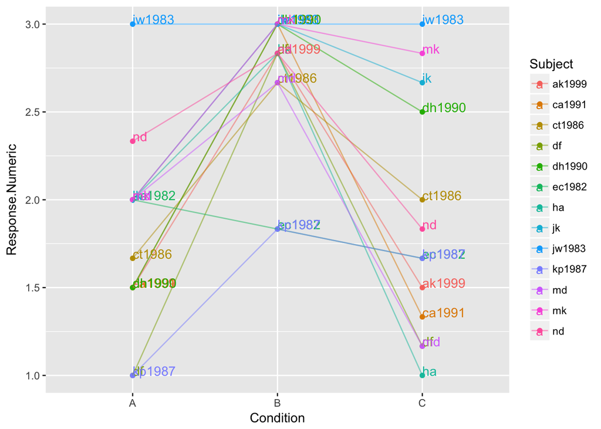

```r
offline_data.subject<- aggregate(Response.Numeric~Subject+Condition, data= experimental_items, mean, na.rm=T)
ggplot(offline_data.subject, aes(y=Response.Numeric, x=Condition, colour=Subject, group=Subject, label=Subject)) + geom_point() + geom_line(alpha=.5) +geom_text(aes(label=Subject),hjust=0, vjust=0)
```

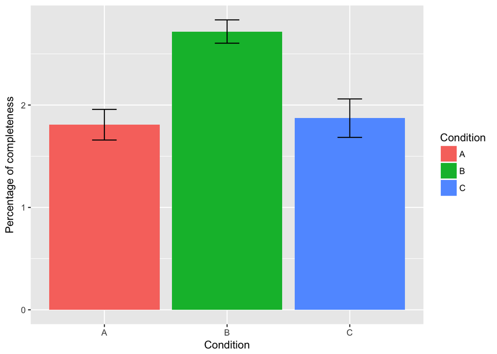

```r
offline_data.overall<- ddply(offline_data.subject, c("Condition"),
                      function(offline_data.subject)c(response=mean(offline_data.subject$Response.Numeric, na.rm=T), se=se(offline_data.subject$Response.Numeric, na.rm=T)))

ggplot(offline_data.overall, aes(y=response, x=Condition, fill=Condition)) +
  geom_bar(position=position_dodge(), stat="identity")  +
  ylab('Percentage of completeness') +
  geom_errorbar(aes(ymin=response-se, ymax=response+se), width=.2, position=position_dodge(.9))
```

### Online response

#### Listening time per chunks in experimental items

NB: ROI = CHUNK 4 (and following given spill over)

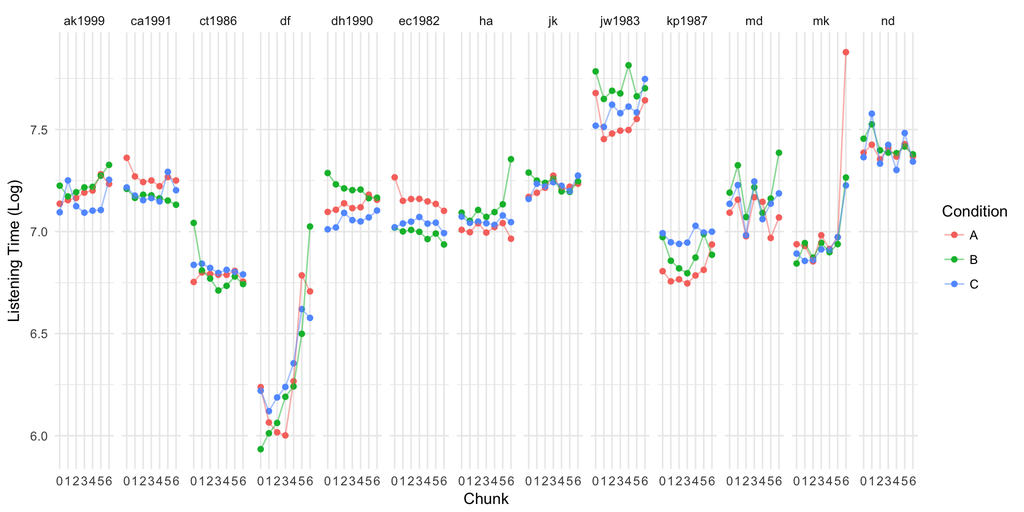

```r
online_data.subject<- aggregate(Chunk.Time.Log~Subject+Condition+X, data= experimental_items, mean, na.rm=T)

ggplot(online_data.subject, aes(y=Chunk.Time.Log, x=X, colour=Condition, group=Condition)) +
  geom_point() +
  geom_line(alpha=.5) +
  facet_grid(.~Subject) +
  theme_minimal() +
  ylab("Listening Time (Log)") +
  xlab("Chunk")
```

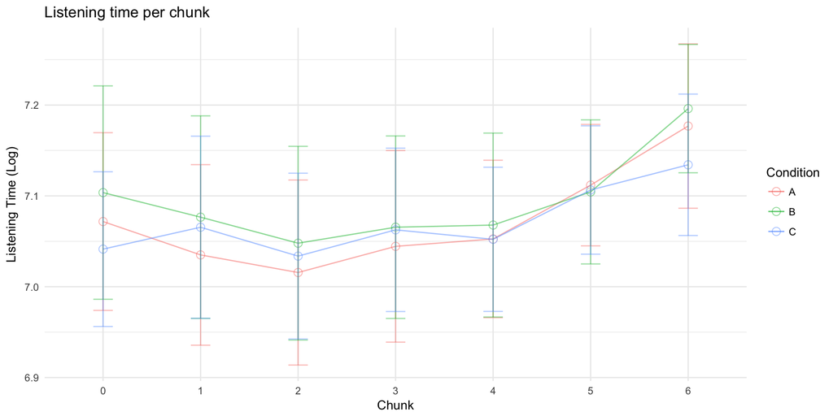

```r
online_data.overall<- ddply(online_data.subject, c("Condition", "X"),
                       function(online_data.subject)c(response=mean(online_data.subject$Chunk.Time.Log, na.rm=T), se=se(online_data.subject$Chunk.Time.Log , na.rm=T)))

ggplot(online_data.overall, aes(y=response, x=X, colour=Condition, group=Condition)) +
  geom_point(size=3, shape=21, fill="white", alpha=.5) +
  geom_line(alpha=.5) +
  theme_minimal() +
  ggtitle('Listening time per chunk') +
  ylab("Listening Time (Log)") +
  xlab("Chunk") +
  geom_errorbar(aes(ymin=response-se, ymax=response+se), alpha=.4, width=.2)
```

#### Listening time per chunks in experimental items

NB: ROI = CHUNK 4 (and following given spill over)

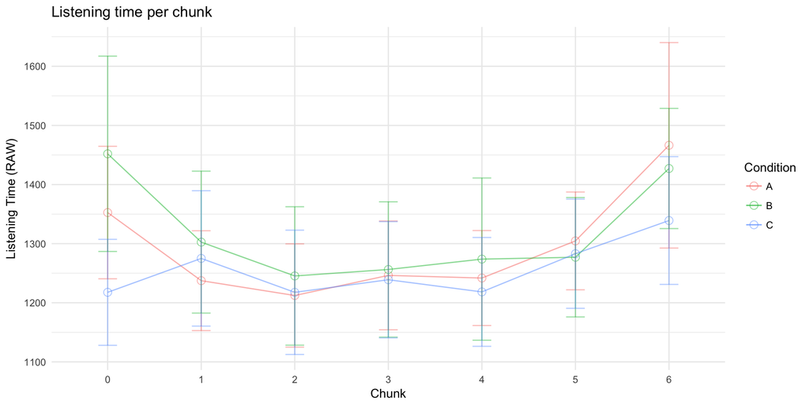

```r
online_data.subject<- aggregate(Chunk.Time~Subject+Condition+X, data= experimental_items, mean, na.rm=T)
online_data.overall<- ddply(online_data.subject, c("Condition", "X"),
                       function(online_data.subject)c(response=mean(online_data.subject$Chunk.Time, na.rm=T), se=se(online_data.subject$Chunk.Time , na.rm=T)))

ggplot(online_data.overall, aes(y=response, x=X, colour=Condition, group=Condition)) +
  geom_point(size=3, shape=21, fill="white", alpha=.5) +
  geom_line(alpha=.5) +
  theme_minimal() +
  ggtitle('Listening time per chunk') +
  ylab("Listening Time (RAW)") +
  xlab("Chunk") +
  geom_errorbar(aes(ymin=response-se, ymax=response+se), alpha=.4, width=.2)
```

#### Listening time for fillers

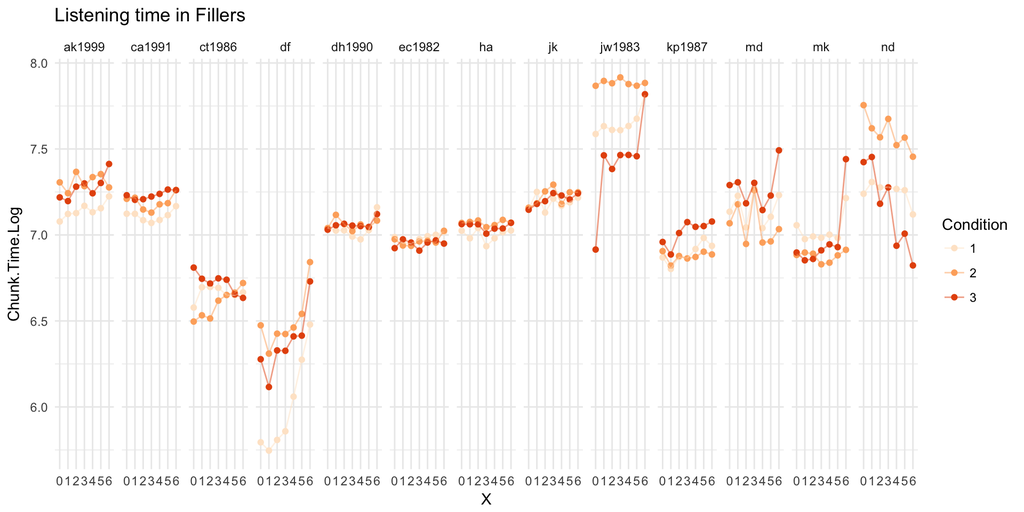

```r
online_data.subject.fillers<- aggregate(Chunk.Time.Log~Subject+Condition+X, data= fillers, mean, na.rm=T)
ggplot(online_data.subject.fillers, aes(y=Chunk.Time.Log, x=X, colour=Condition, group=Condition)) +
  geom_point() +
  geom_line(alpha=.5) +
  scale_colour_brewer(palette='Oranges') +
  ggtitle('Listening time in Fillers')+
  facet_grid(.~Subject) +
  theme_minimal()
```

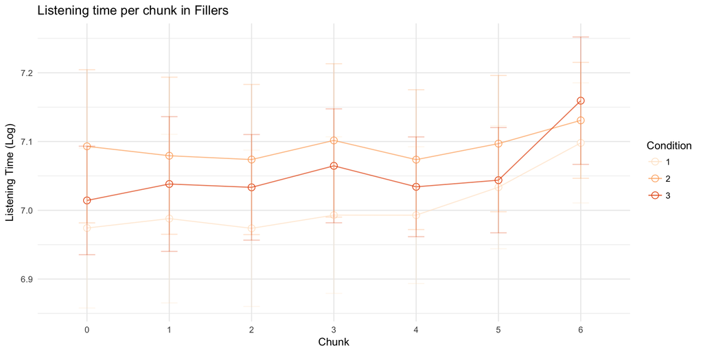

```r
online_data.overall.fillers<- ddply(online_data.subject.fillers, c("Condition", "X"),
                            function(online_data.subject.fillers)c(response=mean(online_data.subject.fillers$Chunk.Time.Log, na.rm=T), se=se(online_data.subject.fillers$Chunk.Time.Log , na.rm=T)))

ggplot(online_data.overall.fillers, aes(y=response, x=X, colour=Condition, group=Condition)) +
  geom_point(size=3, shape=21, fill="white") +
  geom_line(alpha=.7) +
  theme_minimal() +
  scale_color_brewer(palette='Oranges')+
  ggtitle('Listening time per chunk in Fillers') +
  ylab("Listening Time (Log)") +
  xlab("Chunk") +
  geom_errorbar(aes(ymin=response-se, ymax=response+se), alpha=.3, width=.2)
```

#### Total listening time

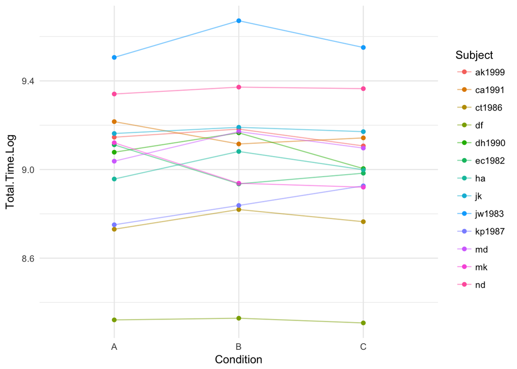

```r
online_data.subject_total <- aggregate(Total.Time.Log~Subject+Condition, data= experimental_items, mean, na.rm=T)
ggplot(online_data.subject_total, aes(y=Total.Time.Log, x=Condition, group=Subject, color=Subject)) + geom_point() + geom_line(alpha=.5) +  theme_minimal()
```

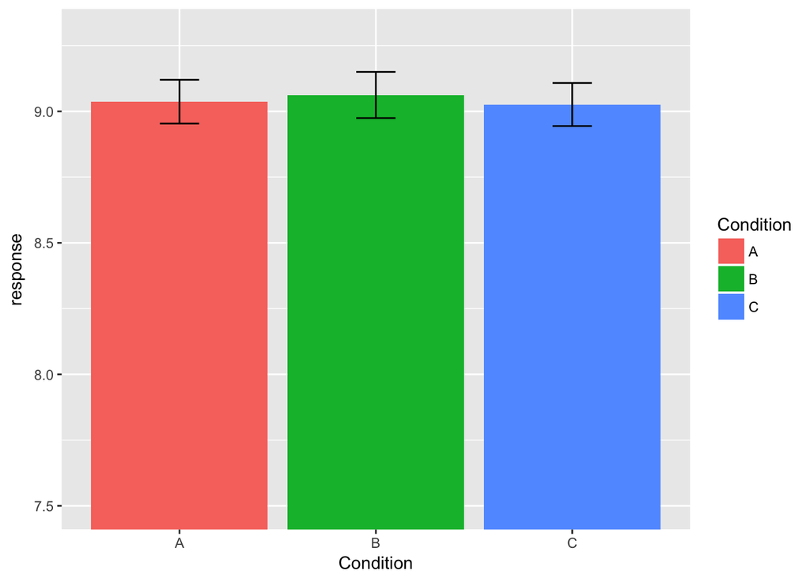

```r
online_data.overall_total<- ddply(online_data.subject_total, c("Condition"),
                            function(online_data.subject_total)c(response=mean(online_data.subject_total$Total.Time.Log, na.rm=T), se=se(online_data.subject_total$Total.Time.Log , na.rm=T)))

ggplot(online_data.overall_total, aes(y=response, x=Condition, fill=Condition)) +
  geom_bar(position=position_dodge(), stat="identity")  +
  coord_cartesian(ylim=c(7.5, 9.3)) +
  geom_errorbar(aes(ymin=response-se, ymax=response+se), width=.2, position=position_dodge(.9))
```